# Introducción a R

Probabilidad Aplicada 3-602

## ¿Qué es R?

R es un lenguaje de programación orientado al análisis estadístico, que nos permite dar indicaciones dentro de un software, para el procesamiento y la visualización de datos.

## ¿Qué es R-Studio?

RStudio es un entorno de desarrollo integrado (IDE) para R, no es el único, pero es el más usado (y la verdad que es muy completo). La interfaz se compone esencialmente de 4 ventanas o paneles:

- **Source:** aquí abrimos los distintos tipos de archivos para escribir nuestras instrucciones y programas. El más común es el script de R, que no es más que una especie de bloc de notas que nos reconoce las palabras reservadas de R y nos ayuda a escribir con autocompletado y mucho más.
- **Console:** es donde se ejecuta las instrucciones y donde visualizamos el estado del procesamiento de las mismas.
- **Environment:** fundamental, acá vemos todos los objetos que vamos creando.
- **Panel:** en donde vemos, los archivos, gráficos, bibliotecas, ayudas y visualizador de objetos del tipo web.  
  Por otro lado, en la barra superior encontramos un montón de ayudas y herramientas que nos permiten personalizar RStudio.

[figure not shown]

## ¿Por qué R?

- Es libre
- Tiene un conjunto importante de paquetes especializados en estadística
- Fácil y flexible acceso a los datos almacenados en diferentes formatos
- Colabora en la limpieza de datos
- Permite hacer una variada gama de análisis, desde exploratorio hasta de modelos predictivos.
- Tiene un gran ecosistema y comunidad de desarrolladores y colaboradores
- Los paquetes se instalan fácilmente
- Trabaja almacenando datos en memoria pero se puede conectar con Hadoop para trabajar con grandes volúmenes de datos (Big Data) en clusters de hardware comercial.
- Utilizaremos el repositorio CRAN para descargar paquetes.

## ¿Cómo descargar e instalar R y Rstudio?

https://www.youtube.com/watch?v=Nmu4WPdJBRo

## Conceptos básicos

### Saber en qué directorio estamos trabajando…

```r
getwd()
```

### Crear un R-project

Crear una carpeta de trabajo donde se desee con el nombre “Primer proyecto”.

**File–>New project**

[figure not shown]

Seleccionamos **Existing Directory** y buscamos la carpeta creada con el nombre “Primer proyecto”

[figure not shown]

### Ver qué paquetes están disponibles

```r
available.packages()
```

### Instalar un paquete

```r
install.packages()
```

### Llamar a un paquete

```r
library('Nombre del paquete')
```

### Obtener ayuda sobre un paquete

```r
?nombre del paquete
```

### Todo es un objeto

Cualquier cosa que existe en R y que tiene un nombre es un OBJETO: gráficos, números, vectores, funciones, secuencias, bases de datos, etc.

```r
estadistica <- "la estadística es una ciencia"
estadistica
```

```
## [1] "la estadística es una ciencia"
```

El comando $<-$ nos permite asignar **“la estadística es una ciencia”** a **estadistica.** ATAJO DE TECLADO ALT + -

### Operadores

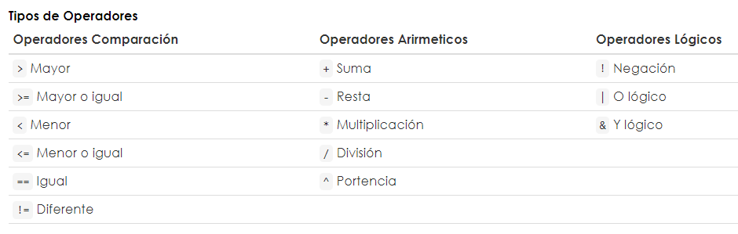

```r
### OPERADORES DE COMPARACION

#definamos un nuevo objeto llamado annalisis matematico
analisis_matematico <- "estudia las funciones"
analisis_matematico
```

```
## [1] "estudia las funciones"
```

```r
#son iguales los objetos estadistica y analisis_matematico?
estadistica==analisis_matematico
```

```
## [1] FALSE
```

```r
#son diferentes?

estadistica!=analisis_matematico
```

```
## [1] TRUE
```

```r
#definimos a=5 y b=3

a <- 5
b <- 3

a < b
```

```
## [1] FALSE
```

```r
a > b
```

```
## [1] TRUE
```

```r
### OPERADORES ARITMETICOS

#Suma
2+3
```

```
## [1] 5
```

```r
#Resta
2-3
```

```
## [1] -1
```

```r
#Division
2/3
```

```
## [1] 0.6666667
```

```r
#Multiplicacion
2*3
```

```
## [1] 6
```

```r
#Potenciacion
2^3
```

```
## [1] 8
```

### Cinco clases básicas de objetos

caracter numerico (numeros reales) enteros complejos logico (True/false)

```r
class(estadistica)
```

```
## [1] "character"
```

```r
class(a)
```

```
## [1] "numeric"
```

### Objetos en R: Vectores

Es el objeto más básico que puede contener objetos de la misma clase. Lo creamos utilizando el comando c().

```r
#definir el vector v=(1,2,3,3,5,7,8,1,9,0,10)
v <- c(1,2,3,3,5,7,8,1,9,0,10)

#Conocer la cantidad de elementos del vector

length(v)
```

```
## [1] 11
```

```r
#Conocecer el elemento que esta en la posicion 4
v[4]
```

```
## [1] 3
```

```r
#Conocer el lugar que ocupa el elemento 3

which(v==3)
```

```
## [1] 3 4
```

```r
#Conocer qué elementos de v son diferentes de 3
which(v!=3)
```

```
## [1]  1  2  5  6  7  8  9 10 11
```